# 1b VLAIO-effect Analysis — Does Public Funding Strengthen the Private Network?

## Context

The Noak co-investment network (Notebook 1) measures ecosystem resilience through **private** investor syndication. VLAIO subsidies are excluded from the network because they are **not co-investment** — startups apply independently, no syndication. However, public funding is a structural pillar of European startup ecosystems.

This notebook answers: **Does VLAIO funding measurably affect a startup's position in the private co-investment network?**

## Data

- `funding_network` — Dealroom + BAN only (private co-investment, Noak-compatible)
- `ooi_startup_context` — O&O&I + KMOGS history per KBO (node attributes, not edges)

## 3-Group Experiment Design

| Group | Definition | Role |
| --- | --- | --- |
| **O&O&I** (experiment) | has_ooi = True (excl KMOGS) | Q1-Q11 VLAIO group |
| **KMOGS-only** (separate) | has_kmogs = True, has_ooi = False | Q8 comparison |
| **Control** (no steun) | has_ooi = False, has_kmogs = False | Q1-Q11 baseline |

KMOGS (kmo-groeisubsidie) is broad SME support (€30K avg), not targeted O&O&I. Including it in the experiment group would dilute the O&O&I signal. It is analysed separately in Q8.

## 11+1 Research Questions

### A. Micro Level — Individual Startup Comparison

| # | Question | Method |
| --- | --- | --- |
| 1 | Do VLAIO-funded startups attract more co-investors? | Degree comparison (bipartite) |
| 2 | Do they attract different types of investors? | Investor-type diversity |
| 3 | Are they bridges between investor clusters? | Betweenness centrality |
| 4 | Are they concentrated or spread across communities? | Chi-squared distribution |
| 5 | Does VLAIO funding precede or follow private capital? | Temporal analysis |
| 6 | How much private capital follows after VLAIO? | Funding multiplier |

### B. Meso Level — Sub-network Comparison

| # | Question | Method |
| --- | --- | --- |
| 7 | Is the VLAIO sub-network more resilient (Noak metrics)? | Full Noak on VLAIO vs non-VLAIO sub-graphs |
| 8 | Which VLAIO programme has the strongest network effect? | Noak per **maatregel_groep** (TRL-based: HS, OND, ONTW, ICON, BAEKELAND, ...) |
| 8b | Do cooperative projects have stronger effects than individual? | Coöperatief vs individueel comparison |
| 9 | How does the VLAIO effect evolve over time? | Temporal snapshots (2014-2018, 2019-2022, 2023-2026) |

### C. Macro Level — Ecosystem Impact

| # | Question | Method |
| --- | --- | --- |
| 10 | How fragile is the ecosystem if VLAIO startups disappear? | Targeted attack simulation |
| 11 | Are VLAIO startups the glue between investor communities? | Percolation threshold analysis |

**Depends on**: Notebook 0 v2 (Data Preparation) → `funding_network` + `ooi_startup_context`

```
Funding network: 1,652 records, 826 startups
Sources: {'dealroom': 1536, 'ban': 116}

O&O&I context: 2,420 TRUE startups with ANY steun
  has_ooi (excl KMOGS): 1,517
  has_kmogs:            1,284
  KMOGS-only:           903
  In private network:   511 (21%)

  ⚠️  4 names appear as both startup AND investor: {'Idalko', 'EnergyVision', 'Aikido Security', 'Winwinner'}
      Removing from investor_set to preserve startup classification.

  ⚠️  Removed 'unknown' placeholder (undisclosed Dealroom rounds).

Bipartite network: 1385 nodes, 1300 edges
  Startups: 826 | Investors: 559
Projected network (largest component): 334 nodes, 786 edges
Communities: 18

============================================================
EXPERIMENT DESIGN (3-group)
============================================================
  O&O&I group (experiment):  430 startups (52%)
  KMOGS-only (separate):     86 startups (10%)
  Control (no steun):        310 startups (38%)
  Total in network:          826 startups

O&O&I group profile:
  Avg grants (excl KMOGS): 6.6
  Avg O&O&I amount: €694,745
  Avg maatregelen: 1.9
  Has cooperatief: 15%
```

# A. Micro Level — Individual Startup Comparison

Compare VLAIO-funded startups vs non-VLAIO startups on network position metrics.

```
================================================================================
Q1: INVESTOR ATTRACTION
================================================================================

VLAIO startups (n=430):
  Mean degree:   1.94 investors
  Median degree: 2.0
  Std:           1.38

Non-VLAIO startups (n=396):
  Mean degree:   1.17 investors
  Median degree: 1.0
  Std:           0.84

Mann-Whitney U test (VLAIO > non-VLAIO):
  U-statistic: 116,134
  p-value:     0.000000
  Significant (p<0.05): YES ✅
  Effect size (r): -0.364
```

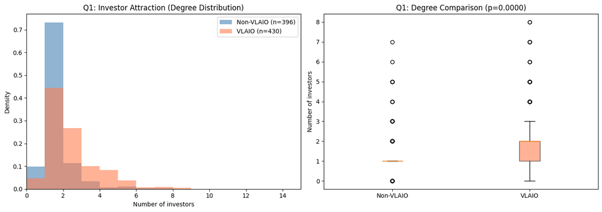